# Practical Machine Learning Course Project

Tianyu Wang

05.08.2020

# Overview

This report analyzes the exercise data of 6 participants of a training study from accelerometers on their belts, forearms, arms and dumbells. The objective is to predict the (correct or incorrect) manner in which they exercised, represented by the `classe` variable in the training data set.

- We start with loading the data and cleaning it to extract only the relevant variables
- We then proceed with predictive modeling by setting up a cross-validation scheme, creating dedicated training as well as testing data sets and applying three different modeling approaches on the training data
- To find the best fitting model with the highest prediction accuracy, we compare the different models and their prediction performance on the test data
- Finally, we apply the best fitting model on the holdout set of new test cases

# Preparation

Load libraries.

```r
library(knitr)
library(rpart.plot)
library(caret)
```

# 1. Loading the Data

Load and inspect the provided data sets for model training and validation:

```r
training <- read.csv("pml-training.csv")
validation <- read.csv("pml-testing.csv")

dim(training)
```

```
## [1] 19622   160
```

```r
dim(validation)
```

```
## [1]  20 160
```

```r
training$classe <- as.factor(training$classe)
```

The training data contains 160 variables over 19.622 observations, while the validation data has 20 observations over the same variables.

# 2. Cleaning and Preparing the Data

Before we can perform predictive modeling, we first need to clean and prepare the training data set to eliminate unwanted or irrelevant characteristics. The validation data set is not changed and only used to generate the final quiz predictions.

At the onset, we remove the first seven columns containing **unnecessary identifiers** of the exercise observations which are not relevant for modeling:

```r
train_prep <- training[, -(1:7)]
dim(train_prep)
```

```
## [1] 19622   153
```

The training data contains multiple columns consisting mostly of **NA values**, so we remove these as they provide no value as features:

```r
train_prep <- train_prep[, colSums(is.na(train_prep)) == 0]
dim(train_prep)
```

```
## [1] 19622    86
```

Variables with very few unique values relative to the number of samples are undesirable for modeling. We apply the `nearZeroVar` function from `caret` to remove such variables with **near zero variance**:

```r
NZV <- nearZeroVar(train_prep)
train_prep <- train_prep[, -NZV]
dim(train_prep)
```

```
## [1] 19622    53
```

```r
set.seed(123456)
inTrain <- createDataPartition(train_prep$classe, p = 0.7, list = F)

trainSet <- train_prep[inTrain,]
dim(trainSet)
```

```
## [1] 13737    53
```

```r
testSet <- train_prep[-inTrain,]
dim(testSet)
```

```
## [1] 5885   53
```

# 3. Building Prediction Models

In this section, we will fit a series of three prediction methods on the prepared training data set to determine the best performing model to be then applied on the validation set eventually. The utilized models are: **Decision tree**, **random forest** and **gradient boosting**.

When training the models, we use **3-fold cross-validation** to improve the model’s ability to predict on new data and reduce overfitting:

```r
fitControl <- trainControl(method = "cv", number = 3)
```

## a. Decision Tree

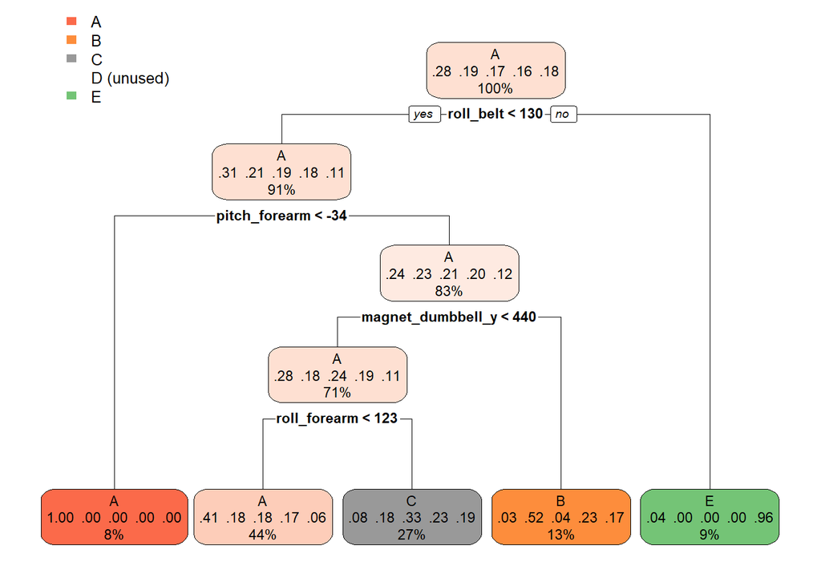

```r
mdl_dt <- train(classe ~ ., data = trainSet, method = "rpart", trControl = fitControl)
rpart.plot(mdl_dt$finalModel)
```

```r
pred_dt <- predict(mdl_dt, testSet)
confusionMatrix(pred_dt, testSet$classe)
```

```
## Confusion Matrix and Statistics
##
##           Reference
## Prediction    A    B    C    D    E
##          A 1506  463  487  427  151
##          B   21  388   41  165  164
##          C  122  288  498  372  259
##          D    0    0    0    0    0
##          E   25    0    0    0  508
##
## Overall Statistics
##
##                Accuracy : 0.4928
##                  95% CI : (0.4799, 0.5056)
##     No Information Rate : 0.2845
##     P-Value [Acc > NIR] : < 2.2e-16
##
##                   Kappa : 0.3374
##
##  Mcnemar's Test P-Value : NA
##
## Statistics by Class:
##
##                      Class: A Class: B Class: C Class: D Class: E
## Sensitivity            0.8996  0.34065  0.48538   0.0000  0.46950
## Specificity            0.6371  0.91761  0.78576   1.0000  0.99479
## Pos Pred Value         0.4964  0.49807  0.32359      NaN  0.95310
## Neg Pred Value         0.9411  0.85292  0.87851   0.8362  0.89275
## Prevalence             0.2845  0.19354  0.17434   0.1638  0.18386
## Detection Rate         0.2559  0.06593  0.08462   0.0000  0.08632
## Detection Prevalence   0.5155  0.13237  0.26151   0.0000  0.09057
## Balanced Accuracy      0.7684  0.62913  0.63557   0.5000  0.73215
```

The decision tree model yields an accuracy of **0.4928** and a high out-of-sample error of **0.5072**, meaning that the outcome cannot reliably predicted this way.

## b. Random Forest

```r
mdl_rf <- train(classe ~ ., data = trainSet, method = "rf", trControl = fitControl)
mdl_rf$finalModel
```

```
##
## Call:
##  randomForest(x = x, y = y, mtry = param$mtry)
##                Type of random forest: classification
##                      Number of trees: 500
## No. of variables tried at each split: 2
##
##         OOB estimate of  error rate: 0.68%
## Confusion matrix:
##      A    B    C    D    E  class.error
## A 3904    1    0    0    1 0.0005120328
## B   19 2632    7    0    0 0.0097817908
## C    0   17 2376    3    0 0.0083472454
## D    0    0   38 2213    1 0.0173179396
## E    0    0    1    6 2518 0.0027722772
```

```r
pred_rf <- predict(mdl_rf, testSet)
confusionMatrix(pred_rf, testSet$classe)
```

```
## Confusion Matrix and Statistics
##
##           Reference
## Prediction    A    B    C    D    E
##          A 1674    3    0    0    0
##          B    0 1134    6    0    0
##          C    0    2 1017   18    0
##          D    0    0    3  944    1
##          E    0    0    0    2 1081
##
## Overall Statistics
##
##                Accuracy : 0.9941
##                  95% CI : (0.9917, 0.9959)
##     No Information Rate : 0.2845
##     P-Value [Acc > NIR] : < 2.2e-16
##
##                   Kappa : 0.9925
##
##  Mcnemar's Test P-Value : NA
##
## Statistics by Class:
##
##                      Class: A Class: B Class: C Class: D Class: E
## Sensitivity            1.0000   0.9956   0.9912   0.9793   0.9991
## Specificity            0.9993   0.9987   0.9959   0.9992   0.9996
## Pos Pred Value         0.9982   0.9947   0.9807   0.9958   0.9982
## Neg Pred Value         1.0000   0.9989   0.9981   0.9959   0.9998
## Prevalence             0.2845   0.1935   0.1743   0.1638   0.1839
## Detection Rate         0.2845   0.1927   0.1728   0.1604   0.1837
## Detection Prevalence   0.2850   0.1937   0.1762   0.1611   0.1840
## Balanced Accuracy      0.9996   0.9972   0.9936   0.9892   0.9993
```

The random forest model yields a very high accuracy of **0.9941** and an out-of-sample error of **0.0059** (which is very good, but could also potentially mean overfitting).

## c. Gradient Boosting

```r
mdl_gbm <- train(classe ~ ., data = trainSet, method = "gbm", verbose = F, trControl = fitControl)
mdl_gbm$finalModel
```

```
## A gradient boosted model with multinomial loss function.
## 150 iterations were performed.
## There were 52 predictors of which 52 had non-zero influence.
```

```r
mdl_gbm
```

```
## Stochastic Gradient Boosting
##
## 13737 samples
##    52 predictor
##     5 classes: 'A', 'B', 'C', 'D', 'E'
##
## No pre-processing
## Resampling: Cross-Validated (3 fold)
## Summary of sample sizes: 9158, 9157, 9159
## Resampling results across tuning parameters:
##
##   interaction.depth  n.trees  Accuracy   Kappa
##   1                   50      0.7529309  0.6869804
##   1                  100      0.8228878  0.7757941
##   1                  150      0.8555734  0.8172073
##   2                   50      0.8512055  0.8114424
##   2                  100      0.9066757  0.8818976
##   2                  150      0.9301165  0.9115662
##   3                   50      0.9001972  0.8736327
##   3                  100      0.9414722  0.9259386
##   3                  150      0.9587247  0.9477806
##
## Tuning parameter 'shrinkage' was held constant at a value of 0.1
##
## Tuning parameter 'n.minobsinnode' was held constant at a value of 10
## Accuracy was used to select the optimal model using the largest value.
## The final values used for the model were n.trees = 150, interaction.depth =
##  3, shrinkage = 0.1 and n.minobsinnode = 10.
```

```r
pred_gbm <- predict(mdl_gbm, testSet)
confusionMatrix(pred_gbm, testSet$classe)
```

```
## Confusion Matrix and Statistics
##
##           Reference
## Prediction    A    B    C    D    E
##          A 1647   41    1    1    1
##          B   14 1067   28    5    5
##          C    7   30  980   27    5
##          D    4    0   15  919   14
##          E    2    1    2   12 1057
##
## Overall Statistics
##
##                Accuracy : 0.9635
##                  95% CI : (0.9584, 0.9681)
##     No Information Rate : 0.2845
##     P-Value [Acc > NIR] : < 2.2e-16
##
##                   Kappa : 0.9538
##
##  Mcnemar's Test P-Value : 0.0003315
##
## Statistics by Class:
##
##                      Class: A Class: B Class: C Class: D Class: E
## Sensitivity            0.9839   0.9368   0.9552   0.9533   0.9769
## Specificity            0.9896   0.9890   0.9858   0.9933   0.9965
## Pos Pred Value         0.9740   0.9535   0.9342   0.9653   0.9842
## Neg Pred Value         0.9936   0.9849   0.9905   0.9909   0.9948
## Prevalence             0.2845   0.1935   0.1743   0.1638   0.1839
## Detection Rate         0.2799   0.1813   0.1665   0.1562   0.1796
## Detection Prevalence   0.2873   0.1901   0.1782   0.1618   0.1825
## Balanced Accuracy      0.9867   0.9629   0.9705   0.9733   0.9867
```

# 4. Validating the Best Performing Model

When looking at these accuracy figures, **random forest** appears to be the best performing model out of the three. Finally, we apply it to the validation data containing the previous unseen 20 test cases, yielding the following **prediction results**:

```r
pred_rf_validation <- predict(mdl_rf, validation)
pred_rf_validation
```

```
##  [1] B A B A A E D B A A B C B A E E A B B B
## Levels: A B C D E
```